# 第三次作业

辛柏嬴 2020111753 20金统2班

2023-03-31

## 第一题

**长度为n = 100 的时间序列{Zt}，已知r1 = 0.615、r2 = 0.505、r3 = 0.364，样本均值 为1.999，样本方差为1.701。为该序列识别一个AR(2) 模型，请计算模型参数的矩估计。**

## 第二题

**使用R 软件模拟样本量为n = 36 的零均值MA(1) 序列，其中θ = −0.6，白噪声 at ∼ N(0, 1)，且模拟设定随机种子数为1。**

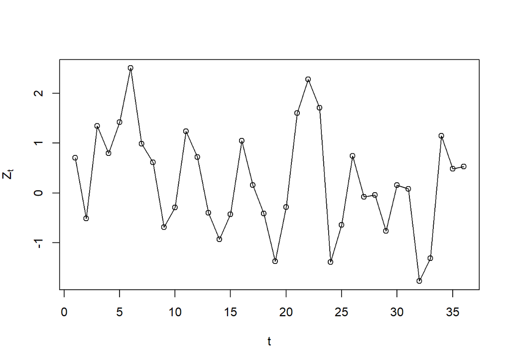

```r
# Z_t = a_t + 0.6a_t-1
#library(TSA)
set.seed(1)
offset <- 300
n <- 36
theta <- -0.6
at <- rnorm(n+offset)
Zt <- NULL
Zt[1] <- at[1]-theta*0
for(i in 2:(n+offset)){
  Zt[i] <- at[i]-theta*at[i-1]
}
Zt <- Zt[(offset+1):(offset+n)]
plot(Zt, type = 'o', main = "", xlab = "t", ylab = expression(Z[t]))
```

**(a) 求θ 的矩估计；**

```r
ma1.mme<-function(x){
r=TSA::acf(x,plot=F)$acf[1];
if (abs(r)<0.5) return((-1+sqrt(1-4*r^2))/(2*r))
else return(NA)}
mme <- ma1.mme(Zt)
cat(paste("MME result:",mme,""))
```

```
## MME result: -0.417855739742642
```

**(b) 求θ 的条件最小二乘估计，并且与(a) 中的结果进行比较；**

```r
arima(Zt, order = c(0,0,1), method = 'CSS')$coef[1]
```

```
##       ma1
## 0.5892244
```

由代码可知，条件最小二乘的计算结果是-0.5892，要明显优于矩估计。

**(c) 求θ 的极大似然估计，并且与(a) 和(b) 中的结果进行比较；**

```r
arima(Zt, order = c(0,0,1), method = 'ML')$coef[1]
```

```
##       ma1
## 0.7224018
```

由代码可知，MLE的估计结果为-0.7224.因此矩估计的效果最差，误差最大；条件最小二乘的估计效果最好，误差最小。

**(d) 设定随机种子数为5，选取相同参数和样本量产生新的模拟序列，使用新的模拟序 列重复(a)、(b) 和(c)，并将两次模拟结果进行比较。**

```r
set.seed(5)
offset <- 300
n <- 36
theta <- -0.6
et <- rnorm(n+offset)
Yt <- NULL
Yt[1] <- et[1]-theta*0
for(i in 2:(n+offset)){
  Yt[i] <- et[i]-theta*et[i-1]
}
Yt <- Yt[(offset+1):(offset+n)]
mme <- ma1.mme(Yt)
print("MME result:")
mme
print("CSS result:")
arima(Yt, order = c(0,0,1), method = 'CSS')
print("MLE result:")
arima(Yt, order = c(0,0,1), method = 'ML')
```

```
## [1] "MME result:"
## [1] -0.4922402
## [1] "CSS result:"
##
## Call:
## arima(x = Yt, order = c(0, 0, 1), method = "CSS")
##
## Coefficients:
##          ma1  intercept
##       0.7102     0.0604
## s.e.  0.1221     0.2626
##
## sigma^2 estimated as 0.8707:  part log likelihood = -48.59
## [1] "MLE result:"
##
## Call:
## arima(x = Yt, order = c(0, 0, 1), method = "ML")
##
## Coefficients:
##          ma1  intercept
##       0.7661     0.0031
## s.e.  0.1099     0.2633
##
## sigma^2 estimated as 0.8196:  log likelihood = -47.94,  aic = 101.89
```